# Smart Retail Insights: Driving Growth Through Sales and Satisfaction Analytics-u3260265

2025-04-19

**Executive summary**

This report explores customer purchasing patterns and revenue drivers through a blend of exploratory data analysis (EDA), visual tools, and predictive modeling techniques. It aims to answer important questions such as which product categories generate the highest and lowest sales, how category preferences vary across age groups, and how factors like gender, age, quantity, and price influence revenue. The report also examines monthly sales patterns to identify seasonal peaks and includes a one-year revenue forecast.

To support the analysis, various methods were applied, including bar charts, pie charts, time series plots, boxplots, correlation analysis, linear regression, decision tree modeling, seasonal naïve forecasting, and residual plots. These tools were used to provide actionable insights for Marry, helping her better understand revenue trends, customer demographics, and satisfaction in order to guide future operational strategies.

Additional findings revealed that the majority of customers are aged between 32 and 61, with no significant age outliers. Cash on Delivery remains the most preferred payment option, and the gender distribution is nearly even. Quantity strongly correlates with revenue, while age shows little to no impact.

Revenue was chosen as the central variable due to its direct importance to business outcomes. Four different predictive models were developed, and the decision tree model proved to be the most effective. With an R² of 0.93, it delivered the highest accuracy and lowest prediction error, outperforming the baseline model, avoiding overfitting, and showing reliable results across the dataset. Residual analysis further validated its consistency, making the decision tree model a robust choice for forecasting future revenue.

```r
library(readr)
library(dplyr)
```

```r
library(ggplot2)
library(tidyr)
library(lubridate)
library(RColorBrewer)
library(scales)
library(corrplot)
library(zoo)
library(Metrics)
library(rpart)
library(forecast)
library(knitr)
library(kableExtra)
```

**Import dataset**

```r
getwd()
```

```
## [1] "C:/Users/NGOCNT/Documents/Case Study report_u3260265"
```

```r
dataset <- read.csv("retail.csv", header = TRUE, sep = ",")
dataset
```

[output not shown]

[output cut: 2988 more lines]

**Abstract of dataset**

This dataset is designed to support the analysis of sales performance, revenue trends, and customer satisfaction for a distribution business operating across multiple product categories, including electronics, sports, home & living, books & stationery, and fashion. The study focuses on a one-year period from March 19, 2024, to March 19, 2025, aligning with Marry’s objective to improve her distribution strategies and service quality. The Online Retail & E-Commerce dataset from Kaggle is used as a proxy for real-world data, offering comprehensive variables such as product ID, category, quantity sold, unit price, review scores, and customer demographics (e.g., age and gender). These attributes enable detailed analysis of sales trends, identification of high- and low-performing products, and exploration of the relationship between customer satisfaction and purchasing behavior. The dataset provides a robust foundation for generating actionable insights to optimize operations, enhance customer experience, and drive business growth in a competitive retail environment.

The e-commerce dataset, covering categories like electronics, sports, home & living, books & stationery, and fashion, provides rich insights into product performance and customer preferences. For electronics (e.g., smartphones, tablets, laptops), high-margin and review-sensitive items benefit from bundling strategies and detailed customer feedback analysis. Sports products like soccer balls are seasonal, making flash promotions and age-targeted bundles effective. Home & living items (e.g., tents, pillows, carpets) depend on durability and comfort, so showcasing high-rated products and encouraging image-based reviews can build trust. Books & stationery (e.g., storybooks, notebooks, pens) are low-cost, bundle-friendly products with strong appeal among students and gift buyers. In fashion (e.g., skirts), trends and return rates dominate, requiring accurate sizing tools and seasonal collections.

In e-commerce, domain expertise in interpreting quantity and price data is essential for optimizing sales strategies, demand forecasting, and inventory management. Quantity sold reflects product demand and customer preference; high volumes may indicate popular, low-cost items (e.g., pens, notebooks), while low volumes with high prices (e.g., laptops, tablets) suggest premium, less frequently purchased goods. Price drives both perception and conversion—price sensitivity varies by category, with fashion and home goods often influenced by promotions, while electronics show steady value retention. Moreover, evaluating unit economics helps identify profit drivers and underperformers. For instance, a product with moderate quantity but high price and positive reviews (e.g., smartphones) may be a strategic item to promote.

**Problem identification**

1. Assess the sales performance across various product categories by identifying which categories generate the highest and lowest total item sales.
2. Examine revenue patterns using bar charts to pinpoint top category within each age group.
3. Correlation relationship between revenue and gender, age, product, category, quantity.
4. Study monthly sales trends to detect peak sales periods and forecast future demand for the next 1 year.
5. Use a variety of modeling approaches to explore the relationship between the key variable, revenue, and other factors including gender, age, category, price, quantity, and review score.

**Show 10 first row of dataset**

```r
head(dataset, n = 10)
```

```
##    customer_id order_date product_id category_id      category_name
## 1        13542 12/17/2024        784          10        Electronics
## 2        23188   6/1/2024        682          50  Sports & Outdoors
## 3        55098   2/4/2025        684          50  Sports & Outdoors
## 4        65208 10/28/2024        204          40 Books & Stationery
## 5        63872  5/10/2024        202          20            Fashion
## 6        29989  12/3/2024        829          10        Electronics
## 7        79809   6/7/2024        706          10        Electronics
## 8        27282  7/15/2024        405          50  Sports & Outdoors
## 9        41394 12/17/2024        549          30      Home & Living
## 10       48695  4/12/2024        545          30      Home & Living
##    product_name quantity  price   payment_method              city review_score
## 1    Smartphone        2 373.36      Credit Card    New Oliviaberg            1
## 2   Soccer Ball        5 299.34      Credit Card      Port Matthew           NA
## 3          Tent        5  23.00      Credit Card        West Sarah            5
```

[output cut: 18 more lines]

**Show data type of variables**

```r
str(dataset)
```

```
## 'data.frame':    1000 obs. of  13 variables:
##  $ customer_id   : int  13542 23188 55098 65208 63872 29989 79809 27282 41394 48695 ...
##  $ order_date    : chr  "12/17/2024" "6/1/2024" "2/4/2025" "10/28/2024" ...
##  $ product_id    : int  784 682 684 204 202 829 706 405 549 545 ...
##  $ category_id   : int  10 50 50 40 20 10 10 50 30 30 ...
##  $ category_name : chr  "Electronics" "Sports & Outdoors" "Sports & Outdoors" "Books & Stationery" ...
##  $ product_name  : chr  "Smartphone" "Soccer Ball" "Tent" "Story Book" ...
##  $ quantity      : int  2 5 5 2 4 4 5 2 3 4 ...
##  $ price         : num  373 299 23 230 177 ...
##  $ payment_method: chr  "Credit Card" "Credit Card" "Credit Card" "Bank Transfer" ...
##  $ city          : chr  "New Oliviaberg" "Port Matthew" "West Sarah" "Hernandezburgh" ...
##  $ review_score  : int  1 NA 5 5 1 5 NA NA 3 5 ...
##  $ gender        : chr  "F" "M" "F" "M" ...
##  $ age           : int  56 59 64 34 33 21 57 60 69 34 ...
```

**Description of each variable**

customer_id: An integer representing a unique customer ID, ranging between 10,000 and 99,999.

order_date: A date field representing a randomly selected date within the past year.

product_id: An integer serving as the product identifier, with values between 100 and 999.

category_id: An integer representing the product category, limited to values 10, 20, 30, 40, or 50.

category_name: A string indicating the name of the product category, such as Electronics, Fashion, Home & Living, Books & Stationery, or Sports & Outdoors.

product_name: A string containing the product’s name, randomly chosen from a list corresponding to its category.

quantity: An integer indicating how many units of the product were ordered, ranging from 1 to 5.

price: A float representing the unit price of the product, ranging from $10.00 to $500.00 with two decimal places.

payment_method: A string denoting the payment method used, which can be Credit Card, Bank Transfer, or Cash on Delivery.

city: A string specifying the customer’s city, generated using the Faker library’s city() method, depending on the locale.

review_score: An integer indicating the customer’s rating of the product, ranging from 1 to 5, or None with a 20% chance.

gender: A string indicating the customer’s gender (either ‘M’ or ‘F’), or None with a 10% chance.

age: An integer representing the customer’s age, ranging from 18 to 75.

**Statistical summary**

This dataset contains 13 columns which is customer_id, order_date, product_id, category_id, category_name, product_name, quantity, price, payment_method, city, review_score, gender and age. Data description was made by applying statistical summary.

```r
summary(dataset)
```

```
##   customer_id     order_date          product_id     category_id
##  Min.   :10201   Length:1000        Min.   :100.0   Min.   :10.00
##  1st Qu.:33857   Class :character   1st Qu.:311.8   1st Qu.:20.00
##  Median :54620   Mode  :character   Median :542.5   Median :30.00
##  Mean   :55491                      Mean   :540.7   Mean   :30.03
##  3rd Qu.:77849                      3rd Qu.:770.8   3rd Qu.:40.00
##  Max.   :99923                      Max.   :995.0   Max.   :50.00
##
##  category_name      product_name          quantity         price
##  Length:1000        Length:1000        Min.   :1.000   Min.   : 10.72
##  Class :character   Class :character   1st Qu.:2.000   1st Qu.:128.53
##  Mode  :character   Mode  :character   Median :3.000   Median :250.22
##                                        Mean   :2.947   Mean   :251.85
##                                        3rd Qu.:4.000   3rd Qu.:366.47
##                                        Max.   :5.000   Max.   :499.50
##
##  payment_method         city            review_score      gender
##  Length:1000        Length:1000        Min.   :1.000   Length:1000
##  Class :character   Class :character   1st Qu.:3.000   Class :character
##  Mode  :character   Mode  :character   Median :4.000   Mode  :character
##                                        Mean   :3.992
##                                        3rd Qu.:5.000
##                                        Max.   :5.000
##                                        NA's   :201
##       age
##  Min.   :18.00
##  1st Qu.:32.00
##  Median :47.00
##  Mean   :46.38
##  3rd Qu.:61.00
##  Max.   :75.00
##
```

Some key observations from the dataset include the quantity of items ordered by customers, which ranges from a minimum of 1 to a maximum of 5, with an average of approximately 3 items per order. The price per order varies between $10.72 and $499.50, with an average value of $251.85. Review scores range from 1 to 5, with an average score of around 4. Notably, 201 customers did not leave a review. The age of customers spans from the youngest at 18 years old to the oldest at 75.

**Create month and year columns**

```r
# Convert 'order_date' from character to Date format using month/day/year
dataset$order_date <- as.Date(dataset$order_date, format = "%m/%d/%Y")

# Add a 'Month' column extracted from 'order_date' in two-digit format (e.g., "03")
dataset <- dataset %>%
  mutate(Month = format(as.Date(order_date, format = "%m/%d/%Y"), "%m"), .after = order_date) %>%

  # Add a 'Year' column extracted from 'order_date' (e.g., "2024")
  mutate(Year = format(as.Date(order_date, format = "%m/%d/%Y"), "%Y"), .after = Month) %>%

  # Create a combined 'Year_Month' column in "YYYY-MM" format
  mutate(Year_Month = format(as.Date(order_date, format = "%m/%d/%Y"), "%Y-%m")) %>%

  # Convert 'order_date' to quarterly format and add as 'Year_Quarter' column
  mutate(Year_Quarter = as.Date(as.yearqtr(order_date, format = "%Y-%m-%d")))

# Display the updated dataset with new time-based columns
print(dataset)
```

[output not shown]

[output cut: 2988 more lines]

**Turn the none-data values in review_score and gender columns into NAs values**

I removed rows containing missing values, which were mainly found in the review_score column (with 20% missing data) and the gender column (with 10% missing data). However, I chose not to completely eliminate all rows with missing values, as doing so could distort the overall analysis of other variables. Instead, for further analysis involving other factors, I retained the dataset and treated the non-data entries in review_score and gender as NA.

```r
# Replace all empty string values ("") in the dataset with NA (missing value)
# This helps standardize missing data for proper analysis
dataset[dataset == ""] <- NA

# Identify which columns contain any NA (missing) values
empty_columns <- dataset %>%
  summarise(across(everything(), ~ any(is.na(.)))) %>%  # Check for NA in all columns
  select(where(~ .)) %>%                                # Select only columns that contain at least one NA
  colnames()                                            # Extract the names of those columns
```

In cases where I specifically analyze the review_score and gender columns, and wish to exclude any missing data, I will completely remove rows containing NA values in these fields to ensure accuracy and consistency in the results.

```r
# Convert empty strings ("") and the string "NA" to actual NA values in all character columns
df_data_cleaned  <- dataset %>%
  mutate(across(where(is.character), ~ na_if(.x, ""))) %>%      # Convert "" to NA
  mutate(across(where(is.character), ~ na_if(.x, "NA")))        # Convert "NA" (as string) to actual NA

# Identify columns that are entirely NA (i.e., all values are missing)
na_columns <- colnames(df_data_cleaned)[colSums(is.na(df_data_cleaned)) == nrow(df_data_cleaned)]

# Remove those all-NA columns from the dataset
df_data_cleaned <- df_data_cleaned %>% select(-all_of(na_columns))

# Remove any rows that contain at least one NA value
df_data_cleaned <- na.omit(df_data_cleaned)

# Display the cleaned dataset
print(df_data_cleaned)
```

[output not shown]

[output cut: 2151 more lines]

**Create new variable**

Upon completing the tasks and addressing the questions below, I recognized that a valuable variable to include in the dataset is “Revenue” (calculated as quantity × price). This variable plays a critical role throughout the analysis, which is why it appears frequently in the tasks and responses. It enables key insights such as gender-based revenue comparisons, identifying top revenue-generating categories by age group, analyzing relationships between revenue and other variables, and forecasting revenue trends over a one-year period.

**Key variable ( aim of model’s prediction)**

In this analysis, revenue was selected as the key variable because it directly reflects the financial outcome of customer transactions and serves as a meaningful measure of business performance. It integrates two core components—price and quantity—which are both essential drivers of sales. To understand what influences revenue, various predictors such as gender, age, category, price, quantity, and review score were examined using exploratory data analysis (EDA).

**Task 1: Payment methods accross each quarter of the year**

I developed a bar chart to analyze the most commonly used payment methods in each quarter of the year, based on total quantity sold. The chart reveals that Cash on Delivery consistently ranks as the most popular payment method across all year-quarters.

```r
# Group by Month and Category to sum the quantity
monthly_category_orders <- dataset %>%
  group_by(Year_Quarter, payment_method) %>%
  summarise(total_quantity = sum(quantity), .groups = 'drop')

# Check unique categories
unique(monthly_category_orders$payment_method)
```

```
## [1] "Bank Transfer"    "Cash on Delivery" "Credit Card"
```

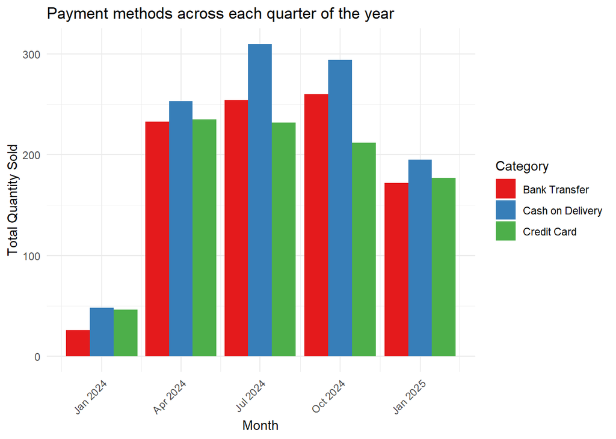

```r
# Plot with bold color palette
ggplot(monthly_category_orders, aes(x = Year_Quarter, y = total_quantity, fill = payment_method)) +
  geom_col(position = "dodge") +
  scale_fill_brewer(palette = "Set1") +
  labs(title = "Payment methods across each quarter of the year",
       x = "Month", y = "Total Quantity Sold",
       fill = "Category") +
  theme_minimal() +
  theme(axis.text.x = element_text(angle = 45, hjust = 1))
```

**Task 2: Outlier analysis using box plot**

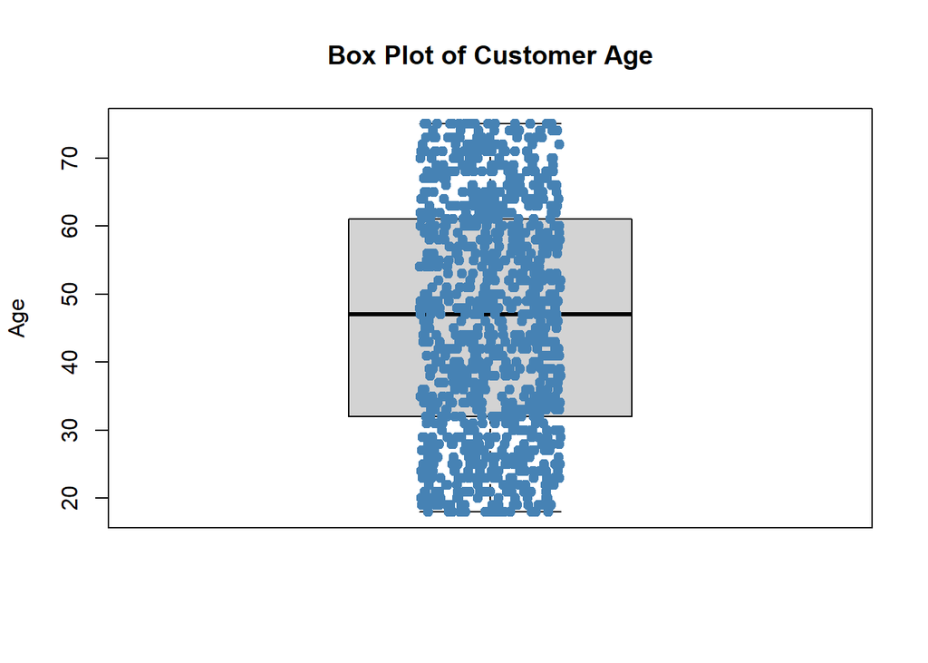

```r
data_for_modeling <- dataset

boxplot(data_for_modeling$age, main="Box Plot of Customer Age", ylab="Age")
# Add points to see the distribution better (optional)
stripchart(data_for_modeling$age, method = "jitter", pch = 19, add = TRUE, col = "steelblue", vertical=TRUE)
```

```r
summary(data_for_modeling$age)
```

```
##    Min. 1st Qu.  Median    Mean 3rd Qu.    Max.
##   18.00   32.00   47.00   46.38   61.00   75.00
```

```r
Q1_age <- quantile(data_for_modeling$age, 0.25, na.rm = TRUE)
Q3_age <- quantile(data_for_modeling$age, 0.75, na.rm = TRUE)
IQR_age <- Q3_age - Q1_age

lower_bound_age <- Q1_age - 1.5 * IQR_age
upper_bound_age <- Q3_age + 1.5 * IQR_age

print(paste("Lower Age Bound (1.5*IQR):", lower_bound_age))
```

```
## [1] "Lower Age Bound (1.5*IQR): -11.5"
```

```r
print(paste("Upper Age Bound (1.5*IQR):", upper_bound_age))
```

```
## [1] "Upper Age Bound (1.5*IQR): 104.5"
```

```r
# Find which values fall outside these bounds
age_outliers <- data_for_modeling$age[data_for_modeling$age < lower_bound_age | data_for_modeling$age > upper_bound_age]
print("Potential Age Outliers based on IQR rule:")
```

```
## [1] "Potential Age Outliers based on IQR rule:"
```

```r
print(age_outliers)
```

```
## integer(0)
```

**Task 3: Distribution of review score**

Bar charts offer several advantages when presenting data. They allow for quick and easy comparison of relative numbers or proportions across multiple categories. By summarizing large datasets in a visual format, bar charts make complex information more accessible and easier to understand. Additionally, they enable viewers to estimate key values at a glance, which aids in fast decision-making and data interpretation (Geographyfieldwork.com, 2025).

```r
# Count the frequency of each review score, including NA values
score_table <- table(data_for_modeling$review_score, useNA = "ifany")  # Show NAs too

# Print frequency table
print("Frequency of each Review Score:")
```

```
## [1] "Frequency of each Review Score:"
```

```r
print(score_table)
```

```
##
##    1    2    3    4    5 <NA>
##   59   51  109  198  382  201
```

```r
# (Redundant print, can be kept for clarity or removed)
print("Frequency of each Review Score:")
```

```
## [1] "Frequency of each Review Score:"
```

```r
print(score_table)
```

```
##
##    1    2    3    4    5 <NA>
##   59   51  109  198  382  201
```

```r
# Calculate the proportion (percentage) of each review score
score_proportions <- prop.table(table(data_for_modeling$review_score))  # Relative frequencies
print("Proportion of each Review Score:")
```

```
## [1] "Proportion of each Review Score:"
```

```r
print(round(score_proportions * 100, 2))  # Convert to percentage and round to 2 decimal places
```

```
##
##     1     2     3     4     5
##  7.38  6.38 13.64 24.78 47.81
```

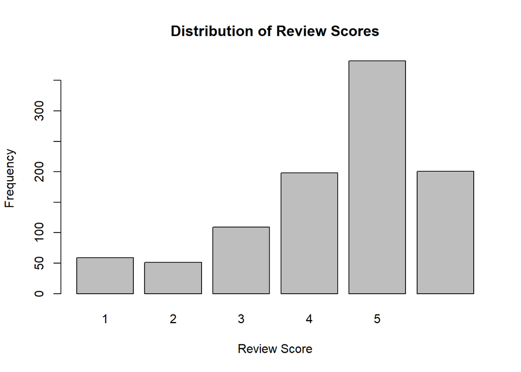

```r
# Create a bar plot showing the frequency distribution of review scores
barplot(score_table,
        main = "Distribution of Review Scores",
        xlab = "Review Score",
        ylab = "Frequency")
```

```r
# Calculate the interquartile range (IQR) for review scores
# Note: This is more useful for continuous numeric variables — use with caution for ordinal or discrete scores
Q1_score <- quantile(data_for_modeling$review_score, 0.25, na.rm = TRUE)
Q3_score <- quantile(data_for_modeling$review_score, 0.75, na.rm = TRUE)
IQR_score <- Q3_score - Q1_score

# Calculate bounds for detecting potential outliers using 1.5*IQR rule
lower_bound_score <- Q1_score - 1.5 * IQR_score
upper_bound_score <- Q3_score + 1.5 * IQR_score

# Print the IQR-based lower and upper bounds
print(paste("Lower Score Bound (1.5*IQR):", lower_bound_score))
```

```
## [1] "Lower Score Bound (1.5*IQR): 0"
```

```r
print(paste("Upper Score Bound (1.5*IQR):", upper_bound_score))
```

```
## [1] "Upper Score Bound (1.5*IQR): 8"
```

```r
# Identify potential outliers in review scores using the IQR rule
score_outliers <- data_for_modeling$review_score[
  data_for_modeling$review_score < lower_bound_score |
  data_for_modeling$review_score > upper_bound_score
]

# Print the potential outliers and their count (note: interpretation depends on score type)
print("Potential Score 'Outliers' based on IQR rule (Use with Caution):")
```

```
## [1] "Potential Score 'Outliers' based on IQR rule (Use with Caution):"
```

```r
print(score_outliers)
```

```
##   [1] NA NA NA NA NA NA NA NA NA NA NA NA NA NA NA NA NA NA NA NA NA NA NA NA NA
##  [26] NA NA NA NA NA NA NA NA NA NA NA NA NA NA NA NA NA NA NA NA NA NA NA NA NA
##  [51] NA NA NA NA NA NA NA NA NA NA NA NA NA NA NA NA NA NA NA NA NA NA NA NA NA
##  [76] NA NA NA NA NA NA NA NA NA NA NA NA NA NA NA NA NA NA NA NA NA NA NA NA NA
## [101] NA NA NA NA NA NA NA NA NA NA NA NA NA NA NA NA NA NA NA NA NA NA NA NA NA
## [126] NA NA NA NA NA NA NA NA NA NA NA NA NA NA NA NA NA NA NA NA NA NA NA NA NA
## [151] NA NA NA NA NA NA NA NA NA NA NA NA NA NA NA NA NA NA NA NA NA NA NA NA NA
## [176] NA NA NA NA NA NA NA NA NA NA NA NA NA NA NA NA NA NA NA NA NA NA NA NA NA
## [201] NA
```

```r
print(paste("Number of potential 'outliers' by IQR:", length(score_outliers)))
```

```
## [1] "Number of potential 'outliers' by IQR: 201"
```

**Task 4: Encode product_name and gender columns** I encoded product_name and gender columns in case I need to analyse numerical variables.

```r
# Encode the 'product_name' column as numeric by converting it to a factor first
# Each unique product name is assigned a unique integer value
dataset$product_name_encoded <- as.numeric(factor(dataset$product_name))

# Encode the 'gender' column as numeric in the same way

dataset$gender_encoded <- as.numeric(factor(dataset$gender))
```

**Task 5: Monthly total sales over time**

I generated a time series line plot to display the total sales for each month. A time series is a sequence of data points arranged in chronological order, used to detect patterns or trends over time (Emery, 2021). The lowest sales were recorded in March 2024, while the highest occurred in December 2024. This suggests that customers tend to shop more towards the end of the year than at the beginning. Following December, sales fluctuated and started to decline.

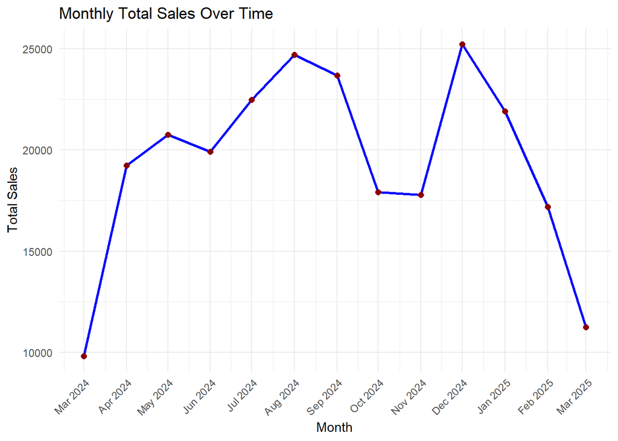

```r
# Ensure Year and Month are numeric
dataset$Year <- as.numeric(as.character(dataset$Year))
dataset$Month <- as.numeric(as.character(dataset$Month))

# Remove rows with missing Month or Year
dataset <- dataset %>% filter(!is.na(Year), !is.na(Month))

# Construct YearMonth safely (e.g., "2023-04-01")
dataset$YearMonth <- as.Date(sprintf("%04d-%02d-01", dataset$Year, dataset$Month), format = "%Y-%m-%d")

# Aggregate sales by month
monthly_sales <- dataset %>%
  group_by(YearMonth) %>%
  summarise(TotalSales = sum(price, na.rm = TRUE)) %>%
  arrange(YearMonth)

# Plot time series
ggplot(monthly_sales, aes(x = YearMonth, y = TotalSales)) +
  geom_line(color = "blue", size = 1) +
  geom_point(color = "darkred", size = 2) +
  labs(title = "Monthly Total Sales Over Time",
       x = "Month",
       y = "Total Sales") +
  theme_minimal() +
  scale_x_date(date_labels = "%b %Y", date_breaks = "1 month") +
  theme(axis.text.x = element_text(angle = 45, hjust = 1))
```

**Task 6: Gender-based revenue comparison of top 10 products**

I developed a bar chart to compare the top 10 revenue-generating products between male and female customers. The top products include headphones, laptops, notebooks, pants, smartphones, smartwatches, soccer balls, T-shirts, tablets, and yoga mats. Interestingly, the yoga mat—typically expected to be more popular among female buyers—was actually purchased more by males, which was an unexpected finding.

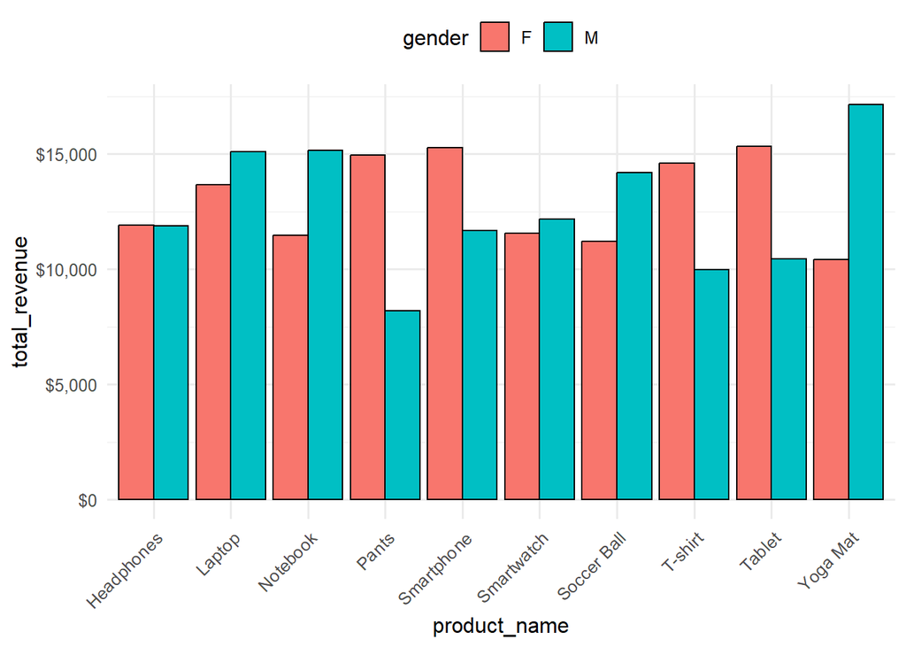

```r
# Identify top 10 products by total revenue
top10_product_tmp <- df_data_cleaned %>%
  mutate(
    revenue = quantity * price  # Calculate revenue for each transaction
  ) %>%
  group_by(product_name) %>%  # Group by product
  summarise(total_revenue = sum(revenue), .groups = 'drop') %>%  # Sum revenue per product
  arrange(desc(total_revenue)) %>%  # Sort in descending order of revenue
  slice(1:10) %>%  # Select the top 10 highest revenue-generating products
  select(product_name)  # Keep only the product name column for filtering

# Calculate total revenue per product-gender combination
top10_product <- df_data_cleaned %>%
  mutate(
    revenue = quantity * price  # Recalculate revenue
  ) %>%
  group_by(product_name, gender) %>%  # Group by both product and gender
  summarise(total_revenue = sum(revenue), .groups = 'drop')  # Sum revenue

# Filter the grouped data to only include the top 10 products
top10_product <- merge(top10_product, top10_product_tmp, by = "product_name")

# Create a bar chart to show revenue by product and gender
bar_chart_top10_product <- ggplot(top10_product,
                                 aes(x = product_name,          # Product names on x-axis
                                     y = total_revenue,         # Total revenue on y-axis
                                     fill = gender)) +          # Fill bars by gender
  geom_col(position = "dodge", color = "black") +               # Use side-by-side bars with black border
  scale_y_continuous(labels = scales::dollar_format()) +       # Format y-axis labels as currency
  theme_minimal(base_size = 12) +                               # Apply a clean, minimalist theme
  theme(
    axis.text.x = element_text(angle = 45, hjust = 1),          # Rotate x-axis labels for better readability
    plot.title = element_text(hjust = 0.5),                     # Center the title (if added)
    legend.position = "top"                                     # Position the legend above the plot
  )

# Display the plot
print(bar_chart_top10_product)
```

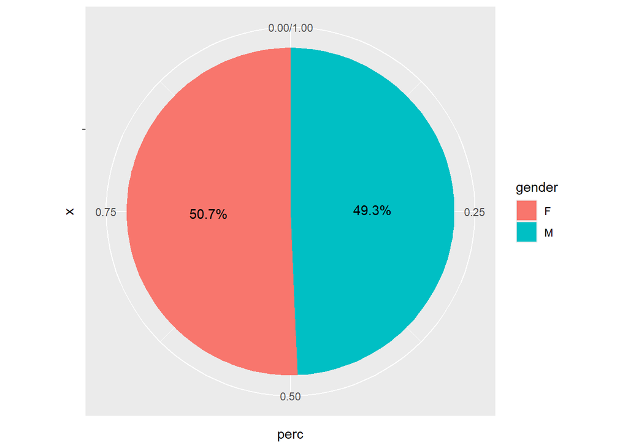

```r
# Create a new data frame 'revenue_gender' by processing 'df_data_cleaned'
revenue_gender <- df_data_cleaned %>%

  # Calculate revenue for each row as quantity multiplied by price
  mutate(
    revenue = quantity * price
  ) %>%

  # Group data by gender
  group_by(gender) %>%

  # Summarize total revenue per gender
  summarise(total_revenue = sum(revenue)) %>%

  # Calculate the percentage share of revenue for each gender
  mutate(perc = total_revenue / sum(total_revenue)) %>%

  # Sort the data by percentage (ascending order)
  arrange(perc) %>%

  # Create percentage labels for plotting (e.g., "50%")
  mutate(labels = percent(perc))
# Generate a pie chart using ggplot2
ggplot(revenue_gender, aes(x = "", y = perc, fill = gender)) +

  # Create the bars for the pie chart (initially as stacked columns)
  geom_col() +

  # Add text labels (percentage) to each section of the pie
  geom_text(aes(label = labels),
            position = position_stack(vjust = 0.5)) +

  # Convert the stacked bar chart into a pie chart
  coord_polar(theta = "y")
```

**Question 1: Top and bottom selling product categories**

I also examined the total quantity sold across different categories. Category 10, representing electronics, saw the highest sales with 648 items sold. Meanwhile Category 40 representing books & stationery saw the lowest sales with 547 items.

```r
# Calculate total quantity sold per category
category_sales_summary <- dataset %>%
  group_by(category_id) %>%
  summarise(
    total_quantity_sold = sum(quantity, na.rm = TRUE) # Sum quantities, ignore NAs if any
  ) %>%
  arrange(desc(total_quantity_sold)) # Arrange from highest to lowest sales

# Display the summary table
print("Total Items Sold per Category (Sorted):")
```

```
## [1] "Total Items Sold per Category (Sorted):"
```

```r
print(category_sales_summary)
```

```
## # A tibble: 5 × 2
##   category_id total_quantity_sold
##         <int>               <int>
## 1          10                 648
## 2          50                 625
## 3          20                 564
## 4          30                 563
## 5          40                 547
```

I created the bar chart total items sold per category to assess the sales performance across various product categories by identifying which categories generate the highest and lowest total item sales.

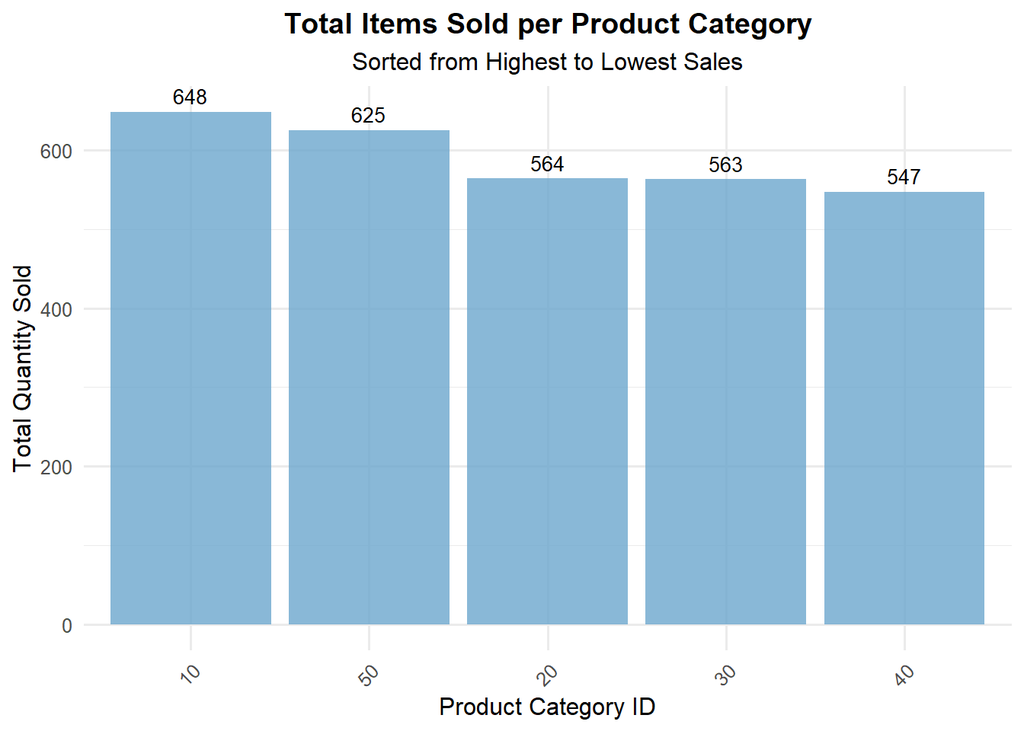

```r
# Create the bar chart using ggplot2
sales_plot <- ggplot(category_sales_summary,
                     # Use reorder to sort bars by total_quantity_sold
                     aes(x = reorder(category_id, -total_quantity_sold),
                         y = total_quantity_sold)) +
  geom_bar(stat = "identity", fill = "skyblue3", alpha = 0.8) + # Create the bars
  geom_text(aes(label = comma(total_quantity_sold)), # Add labels on top of bars
            vjust = -0.5, size = 3.5, color = "black") +
  scale_y_continuous(labels = comma) + # Format y-axis labels with commas
  labs(
    title = "Total Items Sold per Product Category",
    subtitle = "Sorted from Highest to Lowest Sales",
    x = "Product Category ID",
    y = "Total Quantity Sold"
  ) +
  theme_minimal(base_size = 12) +
  theme(
    axis.text.x = element_text(angle = 45, hjust = 1), # Rotate x-axis labels if they overlap
    plot.title = element_text(hjust = 0.5, face = "bold"), # Center title
    plot.subtitle = element_text(hjust = 0.5)
   )

# Print the plot
print(sales_plot)
```

**Question 2: Top revenue-generating category by different age groups**

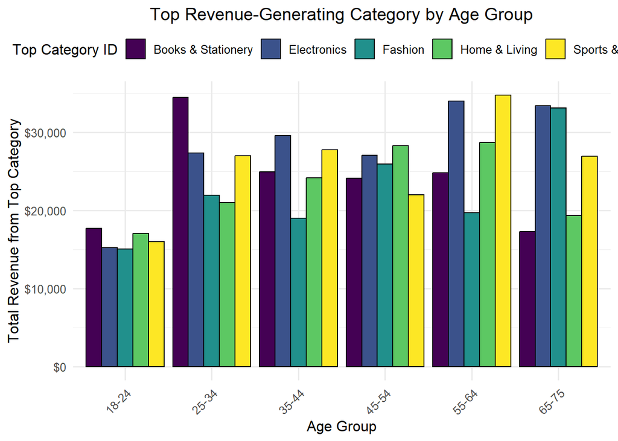

```r
# Define age group breakpoints and corresponding labels
age_breaks <- c(17, 24, 34, 44, 54, 64, 75)  # Breakpoints: groups like 18–24, 25–34, ..., 65–75
age_labels <- c("18-24", "25-34", "35-44", "45-54", "55-64", "65-75")  # Corresponding labels

# Create age group variable and compute revenue for each row
revenue_category_age <- dataset %>%
  mutate(
    age_group = cut(age, breaks = age_breaks, labels = age_labels, right = TRUE, include.lowest = TRUE),  # Categorize age
    revenue = quantity * price  # Calculate revenue per transaction
  )

# Group by category and age group, then summarize total revenue
revenue_category_age <- revenue_category_age %>%
  group_by(category_name, age_group) %>%
  summarise(total_revenue = sum(revenue), .groups = 'drop')  # Summarize revenue per group

# Convert category_name to factor for proper grouping and coloring in the plot
revenue_category_age$category_name_factor <- as.factor(revenue_category_age$category_name)

# Create a grouped bar chart showing revenue by category and age group
bar_chart_top_category <- ggplot(revenue_category_age,
                                 aes(x = age_group,                 # X-axis: Age groups
                                     y = total_revenue,             # Y-axis: Revenue
                                     fill = category_name_factor)) +  # Fill bars by category
  geom_col(position = "dodge", color = "black") +                    # Side-by-side bars with black borders
  scale_y_continuous(labels = scales::dollar_format()) +            # Format Y-axis as currency
  scale_fill_viridis_d(option = "D") +                               # Use colorblind-friendly viridis palette
  labs(
    title = "Top Revenue-Generating Category by Age Group",          # Plot title
    x = "Age Group",
    y = "Total Revenue from Top Category",
    fill = "Top Category ID"                                         # Legend title
  ) +
  theme_minimal(base_size = 12) +                                    # Clean minimal theme with readable font size
  theme(
    axis.text.x = element_text(angle = 45, hjust = 1),               # Rotate x-axis text for readability
    plot.title = element_text(hjust = 0.5),                          # Center the plot title
    legend.position = "top"                                          # Place legend above the plot
  )

# Display the plot
print(bar_chart_top_category)
```

**Question 3: Correlation relationship between revenue and gender, age, product, category, quantity**

The benefit of using the correlation method is its ability to assist researchers in forecasting future behavior. By uncovering a connection between two variables, researchers can use that relationship to predict how alterations in one variable might influence the other (Anon, 2024).

The quantity variable shows a strong positive correlation with revenue (0.61), which is expected given that revenue is calculated as quantity multiplied by price. The product variable has a very weak positive correlation (0.04), indicating that product type has minimal direct impact on total revenue after encoding. Both category and gender exhibit weak negative correlations with revenue (-0.05 and -0.03, respectively), while age demonstrates virtually no correlation, suggesting it has no significant relationship with revenue.

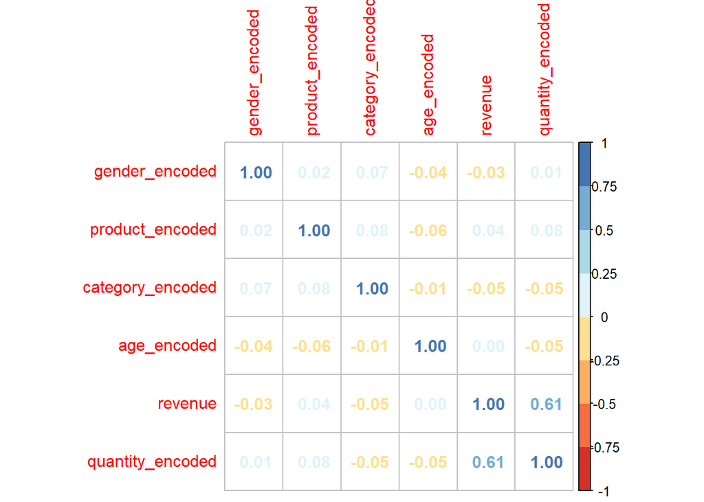

```r
# Start from the cleaned dataset and encode necessary variables for correlation analysis
df_data_cleaned <- df_data_cleaned %>%
  mutate(
    quantity_encoded = as.numeric(factor(quantity)),          # Encode quantity as a numeric factor
    gender_encoded = as.numeric(factor(gender)),              # Encode gender as numeric (e.g., Male = 1, Female = 2)
    age_encoded = as.numeric(factor(age)),                    # Encode age as numeric (for consistency in correlation)
    review_encoded = as.numeric(factor(review_score)),        # Encode review_score as numeric
    category_encoded = as.numeric(factor(category_id)),       # Encode category_id as numeric
    product_encoded = as.numeric(factor(product_name)),       # Encode product_name as numeric
    revenue = quantity * price                                # Calculate revenue
  )

# Select relevant encoded variables and revenue for correlation analysis
df_cor <- df_data_cleaned %>%
  select(revenue, product_encoded, quantity_encoded, gender_encoded, age_encoded, category_encoded)

# Generate a correlation plot (heatmap with numbers) to show relationships between variables
corrplot(cor(df_cor),                       # Compute and plot correlation matrix
         method = "number",                 # Show correlation coefficients as numbers
         order = "hclust",                  # Cluster similar variables together for easier interpretation
         col = brewer.pal(n = 8, name = "RdYlBu"))  # Use a diverging color palette for visual effect
```

**Question 4: 1-Year forecast of revenue trend**

Seasonal naïve forecasting helps improve prediction accuracy for products with distinct seasonal trends by factoring in expected seasonal fluctuations (Launch Fulfillment, 2024).

```r
# Prepare date and revenue columns
dataset <- dataset %>%
  mutate(
    order_date = as.Date(order_date, format = "%m/%d/%Y"),      # Convert order_date from character to Date
    YearMonth = format(order_date, "%Y-%m"),                    # Extract Year-Month as a string (e.g., "2024-03")
    revenue = price * quantity                                  # Calculate revenue per transaction
  )

# Aggregate monthly revenue by YearMonth
monthly_revenue <- dataset %>%
  group_by(YearMonth) %>%
  summarise(total_revenue = sum(revenue), .groups = "drop")     # Sum revenue for each month

# Convert YearMonth string to proper Date object (first of the month)
monthly_revenue$YearMonth <- as.Date(paste0(monthly_revenue$YearMonth, "-01"))

# Create a time series object with monthly frequency
ts_revenue <- ts(monthly_revenue$total_revenue, frequency = 12)

# Fit a seasonal naive forecast model for the next 12 months
fit_snaive <- snaive(ts_revenue, h = 12)
print(summary(fit_snaive))  # Display forecast summary
```

```
##
## Forecast method: Seasonal naive method
##
## Model Information:
## Call: snaive(y = ts_revenue, h = 12)
##
## Residual sd: 597.34
##
## Error measures:
##                  ME   RMSE    MAE      MPE     MAPE MASE ACF1
## Training set 597.34 597.34 597.34 1.913428 1.913428    1   NA
##
## Forecasts:
##       Point Forecast    Lo 80    Hi 80    Lo 95    Hi 95
## Feb 2       50375.40 49609.88 51140.92 49204.64 51546.16
## Mar 2       61448.18 60682.66 62213.70 60277.42 62618.94
## Apr 2       59127.40 58361.88 59892.92 57956.64 60298.16
## May 2       57939.86 57174.34 58705.38 56769.10 59110.62
## Jun 2       79070.12 78304.60 79835.64 77899.36 80240.88
## Jul 2       69323.09 68557.57 70088.61 68152.33 70493.85
## Aug 2       55328.98 54563.46 56094.50 54158.22 56499.74
## Sep 2       55404.74 54639.22 56170.26 54233.98 56575.50
## Oct 2       78432.94 77667.42 79198.46 77262.18 79603.70
## Nov 2       60210.83 59445.31 60976.35 59040.07 61381.59
## Dec 2       48826.04 48060.52 49591.56 47655.28 49996.80
## Jan 3       31218.32 30452.80 31983.84 30047.56 32389.08
```

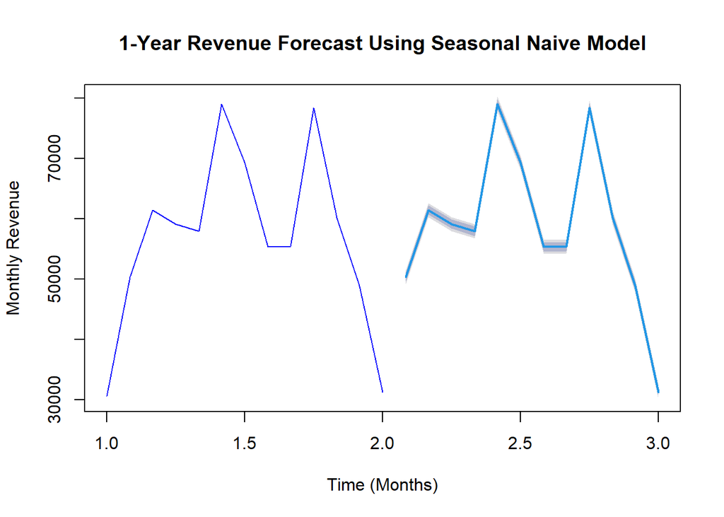

```r
# Plot the forecast
plot(fit_snaive,
     main = "1-Year Revenue Forecast Using Seasonal Naive Model",  # Chart title
     xlab = "Time (Months)",                                       # X-axis label
     ylab = "Monthly Revenue",                                     # Y-axis label
     col = "blue")                                                 # Line color
```

**Question 5: Explore the relationship between the key variable, revenue, and other factors including gender, age, category, price, quantity, and review score**

Relevant features were selected, and the data was then split into training (80%) and testing (20%) sets using a fixed random seed for reproducibility.

```r
# Add revenue-related columns to the cleaned dataset
df_data_cleaned <- df_data_cleaned %>%
  mutate(
    revenue = price * quantity,              # Calculate revenue for each transaction
    log_revenue = log(revenue + 1)           # Compute log-transformed revenue (add 1 to avoid log(0))
  )

# Select relevant columns for modeling
data_model <- df_data_cleaned %>%
  select(
    revenue,                                 # Target variable
    age, gender,                             # Demographic features
    quantity, price,                         # Transactional features
    product_encoded,                         # Encoded product name
    review_score, category_name,             # Additional product/customer features
    log_revenue                              # Transformed target variable for alternate modeling
  )

# Split the data into training (80%) and testing (20%) sets
set.seed(123)                                # Set seed for reproducibility
train_index <- sample(nrow(data_model), 0.8 * nrow(data_model))  # Randomly select 80% of the rows

train_data <- data_model[train_index, ]      # Training dataset
test_data  <- data_model[-train_index, ]     # Testing dataset
```

The first model serves as a simple baseline to assess how well core predictors such as quantity, price, review score, gender, and age explain revenue. It uses a linear approach to evaluate the direct influence of these features, offering a quick benchmark for comparison with more complex models (GeeksforGeeks, 2020). However, the model assumes linear relationships between variables and revenue, which limits its ability to detect interactions or capture nonlinear patterns in the data.

```r
# Fit a baseline linear regression model
# Predict revenue using quantity, price, review score, gender, and age as predictors
model1 <- lm(revenue ~ quantity + price + review_score + gender + age, data = train_data)

# Display a summary of the model
# This includes coefficients, R-squared, p-values, and other model diagnostics
summary(model1)
```

```
##
## Call:
## lm(formula = revenue ~ quantity + price + review_score + gender +
##     age, data = train_data)
##
## Residuals:
##     Min      1Q  Median      3Q     Max
## -528.15 -114.59    2.57  113.49  521.30
##
## Coefficients:
##                Estimate Std. Error t value Pr(>|t|)
## (Intercept)  -698.76786   44.00479 -15.879   <2e-16 ***
## quantity      250.26971    5.87956  42.566   <2e-16 ***
## price           2.94172    0.06015  48.910   <2e-16 ***
## review_score  -15.94068    6.82829  -2.335   0.0199 *
## genderM       -23.47321   16.74262  -1.402   0.1615
## age             0.73188    0.50227   1.457   0.1456
## ---
## Signif. codes:  0 '***' 0.001 '**' 0.01 '*' 0.05 '.' 0.1 ' ' 1
##
## Residual standard error: 200.7 on 570 degrees of freedom
## Multiple R-squared:  0.8786, Adjusted R-squared:  0.8775
## F-statistic: 824.7 on 5 and 570 DF,  p-value: < 2.2e-16
```

This interaction model aims to account for the differing impacts that product types or categories have on revenue. By including an interaction term between quantity and category, it reflects that purchasing multiple units of one product (e.g., books) does not have the same revenue implication as purchasing the same quantity of another (e.g., electronics). The model structure, revenue ~ quantity, category name + age + gender, allows for these nuanced differences to be captured. This approach improves upon simpler models by incorporating the interaction effect, enabling a more accurate representation of how product category influences revenue outcomes through quantity.

```r
# Fit an interaction linear regression model
# This model includes an interaction term between quantity and category_name,allowing the effect of quantity on revenue to vary by category
model2 <- lm(revenue ~ quantity * category_name + age + gender, data = train_data)

# Display the model summary
# Provides details such as coefficients, significance levels, and overall fit (R²)
summary(model2)
```

```
##
## Call:
## lm(formula = revenue ~ quantity * category_name + age + gender,
##     data = train_data)
##
## Residuals:
##      Min       1Q   Median       3Q      Max
## -1264.60  -247.64     7.16   243.25  1216.37
##
## Coefficients:
##                                         Estimate Std. Error t value Pr(>|t|)
## (Intercept)                              -84.557    112.185  -0.754   0.4513
## quantity                                 286.683     30.550   9.384   <2e-16
## category_nameElectronics                 122.428    135.604   0.903   0.3670
## category_nameFashion                      87.219    136.265   0.640   0.5224
## category_nameHome & Living                 7.985    132.995   0.060   0.9521
## category_nameSports & Outdoors           138.269    135.245   1.022   0.3071
## age                                        1.127      1.152   0.978   0.3284
## genderM                                  -25.504     38.416  -0.664   0.5070
## quantity:category_nameElectronics        -47.296     42.042  -1.125   0.2611
## quantity:category_nameFashion            -63.017     43.330  -1.454   0.1464
## quantity:category_nameHome & Living      -23.737     42.684  -0.556   0.5783
## quantity:category_nameSports & Outdoors  -76.533     43.063  -1.777   0.0761
##
## (Intercept)
## quantity                                ***
## category_nameElectronics
## category_nameFashion
## category_nameHome & Living
## category_nameSports & Outdoors
## age
## genderM
## quantity:category_nameElectronics
## quantity:category_nameFashion
## quantity:category_nameHome & Living
## quantity:category_nameSports & Outdoors .
## ---
## Signif. codes:  0 '***' 0.001 '**' 0.01 '*' 0.05 '.' 0.1 ' ' 1
##
## Residual standard error: 457.2 on 564 degrees of freedom
## Multiple R-squared:  0.3765, Adjusted R-squared:  0.3643
## F-statistic: 30.96 on 11 and 564 DF,  p-value: < 2.2e-16
```

The decision tree model is designed for non-linear modeling and offers high interpretability by identifying decision rules and thresholds. This model is well-suited for capturing complex relationships and interactions through hierarchical splits, and it performs well even with skewed or irregular data distributions. Unlike linear models, it does not rely on assumptions of linearity or normality, making it a flexible and robust alternative for modeling revenue.

```r
# Fit a decision tree regression model using the 'rpart' package
# The model predicts revenue based on quantity, price, category, age, and gender
# 'method = "anova"' specifies that this is a regression tree (for continuous target)
tree_model <- rpart(revenue ~ quantity + price + category_name + age + gender,
                    data = train_data,
                    method = "anova")

# Print a summary of the tree model
# This shows the splits, node statistics, and variable importance
summary(tree_model)
```

```
## Call:
## rpart(formula = revenue ~ quantity + price + category_name +
##     age + gender, data = train_data, method = "anova")
##   n= 576
##
##            CP nsplit  rel error     xerror        xstd
## 1  0.35296201      0 1.00000000 1.00394284 0.063063217
## 2  0.28218182      1 0.64703799 0.62217928 0.035225765
## 3  0.09361613      2 0.36485617 0.40071633 0.023953873
## 4  0.07320867      3 0.27124004 0.28931239 0.016348560
## 5  0.05586011      4 0.19803138 0.22706300 0.013490892
## 6  0.02362414      5 0.14217127 0.18616777 0.010356325
## 7  0.01720866      6 0.11854713 0.15685393 0.008934476
## 8  0.01472311      7 0.10133847 0.11325224 0.006704934
## 9  0.01183934      8 0.08661536 0.10406005 0.005974101
## 10 0.01069380      9 0.07477602 0.09095911 0.005191793
## 11 0.01000000     10 0.06408222 0.08100531 0.004815591
##
## Variable importance
##         price      quantity           age category_name        gender
##            49            45             3             2             1
##
## Node number 1: 576 observations,    complexity param=0.352962
##   mean=735.353, MSE=328261.3
##   left son=2 (364 obs) right son=3 (212 obs)
##   Primary splits:
##       price         < 320.6   to the left,  improve=3.529620e-01, (0 missing)
##       quantity      < 2.5     to the left,  improve=3.015011e-01, (0 missing)
##       category_name splits as  LRLLL,       improve=7.181253e-03, (0 missing)
##       age           < 18.5    to the left,  improve=6.233181e-03, (0 missing)
##       gender        splits as  LR,          improve=9.834174e-08, (0 missing)
##
## Node number 2: 364 observations,    complexity param=0.09361613
##   mean=475.5817, MSE=123875.3
##   left son=4 (181 obs) right son=5 (183 obs)
##   Primary splits:
##       price         < 162.415 to the left,  improve=0.392560700, (0 missing)
##       quantity      < 2.5     to the left,  improve=0.313109500, (0 missing)
##       category_name splits as  LRLLL,       improve=0.018009020, (0 missing)
##       age           < 71.5    to the right, improve=0.017970550, (0 missing)
```

[output cut: 134 more lines]

```
##
## Node number 19: 58 observations
##   mean=475.2171, MSE=14550.82
##
## Node number 20: 38 observations
##   mean=251.8666, MSE=1911.733
##
## Node number 21: 72 observations
##   mean=586.4151, MSE=22011.81
##
## Node number 30: 37 observations
##   mean=1581.339, MSE=40513.52
##
## Node number 31: 41 observations
##   mean=2060.579, MSE=52887.24
```

This log model addresses the issue of right-skewness in revenue by applying a log transformation to the target variable. It helps to stabilize variance and reduce the influence of extreme values or outliers commonly found in revenue data. The transformation improves model performance by making the distribution of the dependent variable more symmetric, which can lead to better fit and more reliable predictions, especially in models sensitive to non-normality.

```r
# Fit a linear regression model using log-transformed revenue as the target
# This helps handle skewness in revenue and stabilize variance across predictions
log_model <- lm(log_revenue ~ quantity + price + category_name + gender + age, data = train_data)

# Display the model summary
# Includes coefficients, R², and diagnostic statistics for evaluating model fit
summary(log_model)
```

```
##
## Call:
## lm(formula = log_revenue ~ quantity + price + category_name +
##     gender + age, data = train_data)
##
## Residuals:
##      Min       1Q   Median       3Q      Max
## -1.58897 -0.17015  0.06233  0.24269  0.48399
##
## Coefficients:
##                                  Estimate Std. Error t value Pr(>|t|)
## (Intercept)                     3.766e+00  6.345e-02  59.356   <2e-16 ***
## quantity                        3.869e-01  9.553e-03  40.507   <2e-16 ***
## price                           5.232e-03  9.708e-05  53.898   <2e-16 ***
## category_nameElectronics        3.425e-02  4.323e-02   0.792   0.4286
## category_nameFashion            7.599e-02  4.422e-02   1.718   0.0863 .
## category_nameHome & Living      3.983e-02  4.368e-02   0.912   0.3623
## category_nameSports & Outdoors  6.584e-02  4.382e-02   1.503   0.1335
## genderM                         1.796e-02  2.717e-02   0.661   0.5088
## age                            -9.489e-04  8.129e-04  -1.167   0.2436
## ---
## Signif. codes:  0 '***' 0.001 '**' 0.01 '*' 0.05 '.' 0.1 ' ' 1
##
## Residual standard error: 0.3242 on 567 degrees of freedom
## Multiple R-squared:  0.8883, Adjusted R-squared:  0.8867
## F-statistic: 563.8 on 8 and 567 DF,  p-value: < 2.2e-16
```

So the next step, I would evaluate all 4 models based on their RMSE, MAE and R-squared values. Root Mean Squared Error (RMSE) indicates the average magnitude of prediction errors, with lower values reflecting better accuracy. Mean Absolute Error (MAE) also measures average error size but ignores direction, making it less affected by extreme values compared to RMSE. R-squared (R²) represents the proportion of variance in the target variable explained by the model; values closer to 1 indicate strong explanatory power, while negative values suggest the model performs worse than simply predicting the mean (FARSHAD K, 2024).

Four predictive models were developed and assessed using RMSE, MAE, and R² metrics. The baseline linear regression model offered a solid starting point with an R² of 0.89, demonstrating that key predictors like quantity and price effectively explained revenue. However, the decision tree model significantly improved upon this by achieving a lower RMSE (152.86 vs 189.49), lower MAE (117.52 vs 141.77), and a higher R² of 0.93, indicating a better overall fit and more accurate predictions. This improvement is attributed to the decision tree’s ability to automatically capture non-linear relationships and interactions that the baseline linear model could not.

In contrast, the interaction model, which explicitly introduced interaction terms, performed poorly (R² = 0.38), likely due to overfitting or introducing irrelevant complexity. The log-transformed model failed altogether, with a negative R² (-1.75), highlighting issues with misalignment between transformation and model evaluation, and the risk of distortion in target scaling. The decision tree model avoids both pitfalls: it maintains high interpretability while managing data variability without manual transformation or overly complex term structures.

The decision tree not only improves upon the baseline but also offers a robust, flexible, and reliable solution without succumbing to the limitations seen in the other models.

```r
# Define a function to evaluate a model's performance on the test dataset
evaluate_model <- function(model, test_data, target = "revenue") {
  preds <- predict(model, newdata = test_data)                 # Generate predictions using the test data
  actual <- test_data[[target]]                                # Extract actual target values (default: revenue)

  # Calculate performance metrics
  rmse <- sqrt(mean((actual - preds)^2))                       # Root Mean Squared Error
  mae  <- mean(abs(actual - preds))                            # Mean Absolute Error
  r2   <- 1 - sum((actual - preds)^2) / sum((actual - mean(actual))^2)  # R-squared (goodness of fit)

  # Return the metrics as a data frame
  data.frame(RMSE = rmse, MAE = mae, R2 = r2)
}

# Evaluate all four models and compile the results into one data frame
results <- dplyr::bind_rows(
  cbind(Model = "Baseline model",     evaluate_model(model1, test_data)),     # Linear model
  cbind(Model = "Interaction model",  evaluate_model(model2, test_data)),     # Model with interaction term
  cbind(Model = "Decision model",     evaluate_model(tree_model, test_data)), # Decision tree model
  cbind(Model = "Log model",          evaluate_model(log_model, test_data))   # Log-transformed model
)

# Print the comparison of model performance metrics
print(results)
```

```
##               Model     RMSE      MAE         R2
## 1    Baseline model 189.4928 141.7732  0.8920854
## 2 Interaction model 453.2119 354.9800  0.3826982
## 3    Decision model 152.8644 117.5215  0.9297724
## 4         Log model 957.0851 764.3543 -1.7529360
```

I chose the decision tree model to predict and interpret predictions using residuals plot. The residual plot for the decision tree model demonstrates that the model performs well in predicting revenue across most of the dataset. Residuals, which represent the difference between actual and predicted values, are generally centered around zero, indicating that the model does not suffer from systematic overprediction or underprediction. Most predictions, particularly in the low to mid-range of predicted revenue, are tightly clustered around the red dashed line, suggesting high accuracy in these regions. Additionally, the symmetrical and random spread of residuals implies that the model captures the underlying patterns in the data effectively, without leaving significant nonlinear trends unmodeled.

However, there is a noticeable increase in residual spread as predicted revenue increases. This widening dispersion indicates that the model’s predictions become less consistent for high-value transactions. In these cases, the model tends to be less precise, which could be due to fewer high-revenue examples in the training data or the presence of outliers. Despite this, the model still maintains an overall strong predictive performance, and the absence of any distinct residual pattern confirms its robustness.

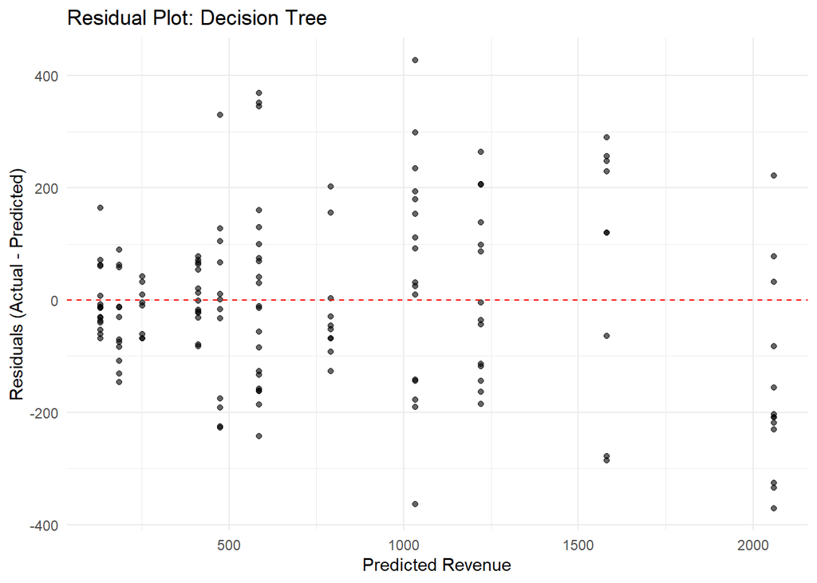

```r
# Predict revenue on the test dataset using the trained decision tree model
tree_predictions <- predict(tree_model, newdata = test_data)

# Calculate residuals (differences between actual and predicted values)
residuals <- test_data$revenue - tree_predictions

# Create a new data frame containing actual values, predicted values, and residuals
results <- data.frame(
  Actual = test_data$revenue,         # Actual revenue values
  Predicted = tree_predictions,       # Predicted revenue from the model
  Residuals = residuals               # Difference: Actual - Predicted
)

# Plot the residuals to evaluate model performance
# This helps identify bias, variance, or patterns that suggest model limitations
ggplot(results, aes(x = Predicted, y = Residuals)) +
  geom_point(alpha = 0.6) +                                      # Plot residuals as semi-transparent points
  geom_hline(yintercept = 0, color = "red", linetype = "dashed") +  # Add horizontal line at 0 to guide residual symmetry
  labs(
    title = "Residual Plot: Decision Tree",                      # Plot title
    x = "Predicted Revenue",                                     # X-axis label
    y = "Residuals (Actual - Predicted)"                         # Y-axis label
  ) +
  theme_minimal()                                                # Use a clean and modern theme
```

**Recommendations & Conclusions**